# Aula Machine Learning (Profa Luciana Correia Alves)

2025-06-03

[figure not shown]

## Definição de Machine Learning (Aprendizado de Máquina) - ML

É um método de análise de dados que automatiza a construção de modelos analíticos. É baseado na ideia de que sistemas podem aprender com dados, identificar padrões e tomar decisões com o mínimo de intervenção humana. A importância desse aprendizado se deve principalmente ao fato de que atualmente tem surgido cada vez mais a necessidade de manipulações de grandes volumes e variedades de dados disponíveis.

Diferentemente das abordagens baseadas em regressão tradicional, o aprendizado de máquina não impõe um modelo paramétrico ligando uma variável dependente a um conjunto de variáveis independentes. A ideia chave é deixar o algoritmo encontrar o caminho para o resultado e ligações entre as variáveis independentes. Desta forma, é possível procurar automaticamente relações e interações entre as variáveis independentes (Massachusetts Institute of Technology- MIT (2021).

É um ramo da inteligência artificial.

É um resultado dessa interação entre a Estatística e a Computação, utilizando modelos estatísticos combinados com algoritmos computacionais para extrair informação de conjuntos de dados com muitas observações e/ou variáveis.

## Exemplos

1. Estimar quantas pessoas vivem em uma área com base em determinados tipos de moradias, densidade demográfica ou outras características da região.
2. Quantas pessoas desenvolverão diabetes e hipertensão com base em detalhes sobre as características demográficas, renda domiciliar, níveis de educação da população e outras características de saúde da população.
3. Estimar a distribuição geográfica de uma população com base na atividade de telefonia móvel.
4. Governos locais podem estimar os pagamentos de pensões futuros para avaliar se a arrecadação atual será suficiente para cobrir essas despesas.
5. Os bancos utilizam modelos preditivos para traçar o perfil dos clientes, auxiliando na oferta de produtos e na gestão de riscos.
6. O Google busca prever se você irá clicar em determinado anúncio, de forma a exibir apenas aqueles com maior chance de receber cliques e, assim, maximizar sua receita.
7. Empresas como Amazon, Netflix e similares recomendam filmes ou séries com base no que você provavelmente terá interesse, com o objetivo de mantê-lo engajado na plataforma e, consequentemente, aumentar seus ganhos.
8. As seguradoras tentam prever seu riscos de óbitos dos indivíduos para vender os seguros.

## Quando Usar?

- Volume grande de dados
- Número grande e variedade de variáveis disponíveis no banco de dados
- Predição (estudos longitudinais)

## Como funciona?

- Modelos para estudar o valor de uma variável resposta (output ou desfecho) a partir de variáveis preditoras (input, variáveis explicativas ou covariáveis).
- Modelos tradicionais também fazem isso.

## O que vai depender a escolha de um e de outro?

- Quantidade e Variabilidade dos Dados
- Big Data

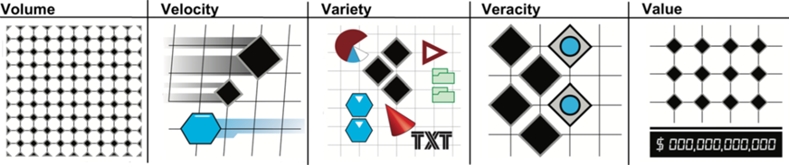

Fuller D, Buote R, Stanley K. J Epidemiol Community Health 2017;71:1113–1117.

[figure not shown]

- Nova disponibilidade de dados
- Representatividade
- Migração, mobilidade, etc.
- Viés

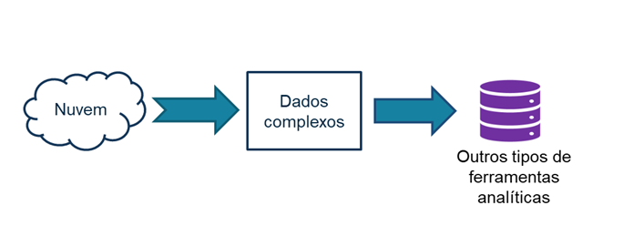

## Novas metodologias

### ML (preditivos)

- Ênfase em predição
- Resultados avaliados via performance da predição
- Preocupação com overfitting
- A generalização é obtida por meio do desempenho em novos conjuntos de dados
- Modelar mundo real

### MT (explicativos)

- Ênfase na inferência
- Foco em teste de hipóteses à priori
- Parcimônia X Performance modelos complexos
- Ênfase na interpretabilidade dos parâmetros
- Pressupostos. Modelo paramétrico
- Causalidade/Associações

## ML x Regressão Tradicional

A modelagem tradicional do tipo regressão pode ser categorizada pelo propósito do modelo, se é necessário prever uma variável dependente dada múltiplas variáveis independentes ou produzir associação estatística de variáveis independentes individuais na variável dependente (Shmueli, 2010).

As modelagens tradicionais são focadas em dados e fazem várias suposições sobre os dados usados no modelo (Breiman, 2001).

Exemplo nos modelos lineares: distribuição normal, linearidade, independência e variância constante são imprescindíveis. Presença de colinearidade.

Questões de pesquisa mais avançadas, datasets maiores, relações não lineares (modelagens tradicionais se tornam mais difíceis de atender) (Bellman, 2015).

Busca padrões, associações, visualizando a complexidade dos fenômenos e prevendo resultados de saúde sem considerar hipóteses formuladas a priori (sem necessariamente partir de uma fundamentação teórica prévia sobre causalidade e associações).

Isso significa fazer a transição de uma abordagem orientada por hipóteses para uma abordagem orientada por dados.

## O Modelo em Si

O Machine Learning ou Aprendizado de Máquina tenta prever um modelo a partir do conjunto de dados disponível (metodologia baseada em dados - Data driven).

## Tipos de Aprendizado de Máquina

### Aprendizado não supervisionado

É um processo no qual a máquina usa dados de entrada para descobrir padrões e relações matemáticas desconhecidas pelos pesquisadores (FULLER; BUOTE; STANLEY, 2017).

Semelhante a mineração de dados.

A máquina tenta encontrar padrões sem direção específica (aplicação em problemas de classificação de imagens. Evolução típica de uma doença).

Ex: Imagem de satélite pode prever a quantidade de pessoas que moram em uma região. Spotify. Netflix. Áreas de vulnerabilidade. Perfil de eleitores e discursos políticos.

### Aprendizado supervisionado

Fornecem as saídas conhecidas para o sistema aprender (tem um alvo).

Ex: Spam ou não spam (email). Risco de desastres. Prevenção de problemas de saúde.Previsão de voto, evasão escolar.

## Sobre a variável de interesse

Se a variável de interesse é uma variável discreta ou categórica: é um problema de **classificação** e o algoritmo utilizado será chamado de **Classificador**.

Se os valores da Variável de Interesse são valores contínuos: é um problema de **regressão** e o algoritmo que criaremos será chamado **Regressor**.

## Predição

Construção de um algoritmo “preditor” capaz de inferir se um dado pertence ou não a uma certa categoria.

## Algoritmos

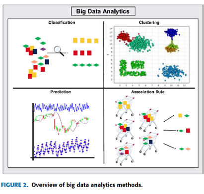

- Random Forest
- Extreme Gradient Boosted Trees
- Naive Bayes
- Support Vector Machine
- Árvores de Classificação
- Boosting
- Método dos k Vizinhos Mais Próximos
- Redes Neurais Artificiais
- Componentes principais (PCA)
- Métodos de regressão
- Regressão logística

## O que é uma Árvore de Decisão?

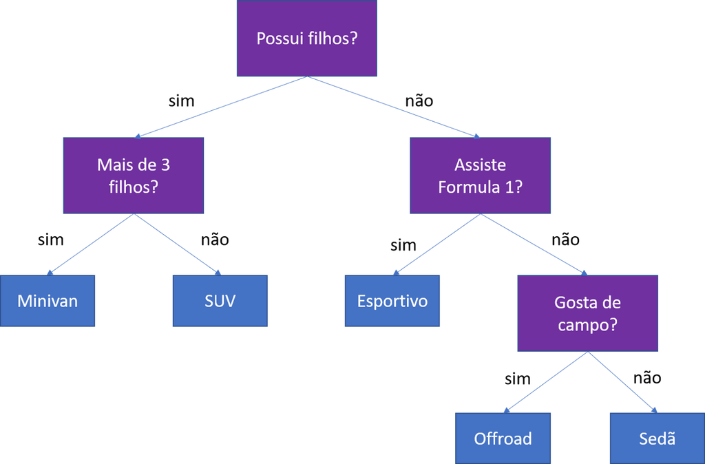

### Random Forest

No método Random Forest, as árvores de decisão são construídas tomando partições aleatoriamente reamostradas dos dados e usando um subconjunto aleatório de variáveis potenciais para informar cada divisão dos dados. Ao criar amostras aleatórias com as observações e determinando possíveis variáveis de divisão, esse método introduz um elemento de aleatoriedade que impede o sobreajuste do modelo. Depois de treinar todas as árvores, elas são combinadas com base nas previsões de cada árvore individual (Kuhn and Johnson, 2013).

### Extreme Gradient Boosted Trees (XGBoost)

O método começa com árvores de aprendizagem fracas e constrõem árvores mais confiáveis com base nos resíduos das previsões de cada árvore anterior. Ele usa uma técnica de otimização conhecida como gradiente descendente para ajustar os pesos dessas árvores e melhorar sua precisão. Além disso, o XGBoost inclui vários recursos, como regularização e parada precoce, que ajudam a prevenir sobreajuste e melhorar o desempenho do modelo. É uma implementação avançada do algoritmo de boosting baseado em árvores de decisão, projetado para lidar com problemas de aprendizado supervisionado, como classificação e regressão (Kuhn and Johnson, 2013).

### Regressão Logística

Baseado nos modelos tradicionais e usado para problemas de classificação. Estima a probabilidade de ocorrência de uma determinada classe a partir de variáveis de entrada. O modelo é treinado a partir de um conjunto de dados de treinamento, ajustando os pesos dos coeficientes de regressão por meio de um algoritmo de otimização para maximizar a verossimilhança dos dados. Uma vez que o modelo é treinado, ele pode ser usado para prever a classe de objetos desconhecidos. O resultado final é uma função que mapeia as variáveis de entrada para a probabilidade de pertencer a uma classe específica (Kuhn and Johnson, 2013).

### Naive Bayes

Investiga a distribuição condicional das variáveis preditoras em cada classe para determinar se há diferenças entre as classes, tratando todos os preditores como independentes. Ou seja, o algoritmo estima Pr[Y=C1|Xn], isto é, dado um determinado valor de uma variável preditora Xn, qual a probabilidade da variável desfecho ser da Classe C1) (Kuhn and Johnson, 2013).

### Support Vector Machine (SVM)

Representa as instâncias como um conjunto de pontos de 2 tipos no lugar N dimensional e gera um hiperplano dimensional (N – 1) para separar esses pontos em 2 grupos. O SVM tenta encontrar um hiperplano de separação que divide esses pontos em dois tipos e que está o mais distante possível de todos esses pontos. Cria uma fronteira que melhor separa os dados calculando os vetores de suporte e está o mais distante possível de todos esses pontos (Kuhn and Johnson, 2013).

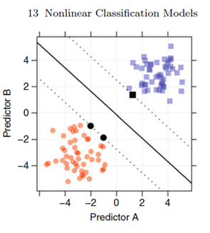

Fonte: Kuhn and Johnson (2013)

### K-means

É um popular algoritmo de aprendizado de máquina não supervisionado usado para agrupar dados. O objetivo do k-means é particionar um conjunto de observações (também conhecido como pontos ou dados) em k clusters, onde cada observação pertence ao cluster com a média mais próxima (também conhecida como centróide) (BISHOP, 2006).

## Etapas do método

### Banco de Dados

- Construção/Seleção.
- Separa uma amostra (10%): para validação.
- O restante da amostra dese ser dividida em Treino e Teste.

### Pré-processamento

- Limpeza dos bancos.
- Tratamento de inconsistência e missings (cont=média no treino/cat=moda).
- Transformação e Centralização.
- One-hot encoding.
- Supervisionado ou não.

### Algoritmos ML

- Aprendizagem (vários passos).
- Validação cruzada.
- Métricas.
- Matriz de confusão do melhor modelo (teste).
- Algoritmos.
- Avaliação de sobreajuste.
- Compara a performance.

### Interpretação e Avaliação

Como apresentar esses resultados?

- Matriz de confusão.
- Curva ROC.
- Gráfico das features importance.
- API.
- Suporte a tomada de decisões humanas.

## Passo-a-passo

- Pré-processamento
- Bancos balanceados vs desbalancedos
- Aprendizado supervisionado e não supervisionado
- Escolha do(s) algoritmo(s)
- k-fold cross validation (validação cruzada)
- Treino (comparação de performances. Métricas) e teste
- Avaliação de hiperparâmetro
- Feature importance

## Validação cruzada (k-fold cross validation)

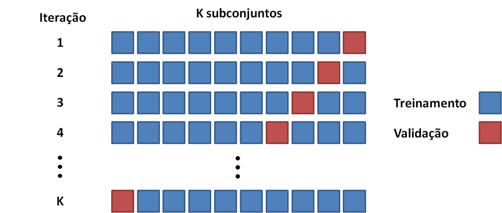

## Matriz de Confusão e Métricas

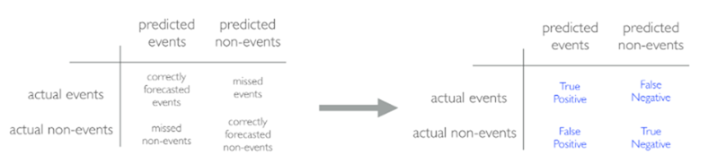

https://bradleyboehmke.github.io/HOML/intro.html

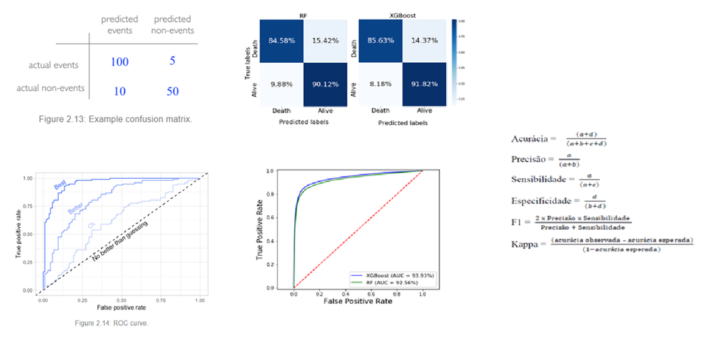

**Sensibilidade (recall)**: é a porcentagem dos elementos da amostra que possuem a característica de interesse e foram corretamente identificados.

**Especificidade:** é a porcentagem dos elementos da amostra que não possuem a característica de interesse e foram corretamente identificados.

**Acurácia:** avalia a porcentagem de acertos (predição correta) do total de predições feitas pelo modelo. O quanto o modelo acerta.

**Precisão:** a capacidade do modelo identificar corretamente os exemplos positivos antre todos os exemplos classificados como positivo.

**F1-score:** é uma métrica que combina precisão e sensibilidade em uma única medida (útil para classes desbalanceadas).

**Kappa:** medida de concordância.

## Importância das variáveis (Feature Importance)

A importância das variáveis é um conceito-chave no aprendizado de máquina que se refere à importância relativa de cada variável nos dados de treinamento. Em outras palavras, ele nos diz quais variáveis são mais preditivas do desfecho. A importância das variáveis/preditoras podem ser calculadas de várias maneiras, mas todos os métodos geralmente dependem do cálculo de algum tipo de pontuação que mede a frequência com que uma variável é usado no modelo e o quanto ele contribui para as previsões gerais.

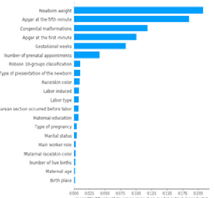

## **Referências:**

BURGER, S.V. Introduction to Machine Learning with R: Rigorous Mathematical Analysis. Beijing: O’Reilly, 2018.

IZBICKI, R. E.; SANTOS, T. M. DOS. Aprendizado de máquina: uma abordagem estatística. 1ᵃ edição. 2020. 272 páginas. ISBN: 978-65-00-02410-4.

KUHN, M.; JOHNSON, K. Applied predictive modeling. New York, NY: Springer, 2013.

KUHN, M. Building predictive models in R using caret package. Journal of Statistical Software, v. 28, n. 5, p. 1-26, 2008.